# Cardiovascular Disease Prediction: Data Analysis and Machine Learning Model Development.

## Clustering Analysis: Elbow Method for Optimal KMeans Clustering.

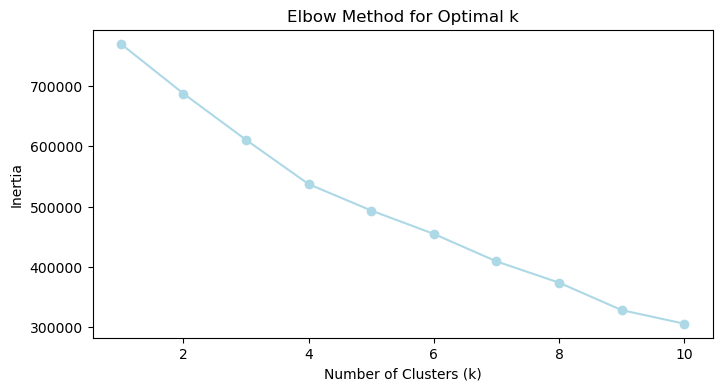

```python
from sklearn.cluster import KMeans

df = df.drop(columns=['id', 'cardio'])

if df.isnull().sum().any():
    df = df.dropna()

scaler = StandardScaler()
df_scaled = scaler.fit_transform(df)

inertia = []
range_clusters = range(1, 11)

for k in range_clusters:
    kmeans = KMeans(n_clusters=k, random_state=42)
    kmeans.fit(df_scaled)
    inertia.append(kmeans.inertia_)


plt.figure(figsize=(8, 4))
plt.plot(range_clusters, inertia, 'bo-',color='lightblue')
plt.xlabel('Number of Clusters (k)')
plt.ylabel('Inertia')
plt.title('Elbow Method for Optimal k')
plt.show()
```

#### Summary: Determine optimal KMeans clusters (k) by plotting inertia against k values and identifying the "elbow" point.

#### Key Insights:

- "Elbow" point suggests optimal k value
- k=3 or k=4 appears optimal in this case
- Balances cluster increase and variance reduction

#### Conclusion: Elbow Method informs cluster granularity and data structure decisions.

### 1. K-Means Clustering with Silhouette Score Evaluation.

```python
kmeans = KMeans(n_clusters=4, random_state=42)
clusters = kmeans.fit_predict(df_scaled)
df['Cluster'] = clusters
```

```python
from sklearn.metrics import silhouette_score

silhouette_avg = silhouette_score(df_scaled, clusters)
print(f'Silhouette Score: {silhouette_avg:.2f}')
```

```
Silhouette Score: 0.23
```

### 2.Visualization of Clustering using PCA with K-Means.

[figure not shown]

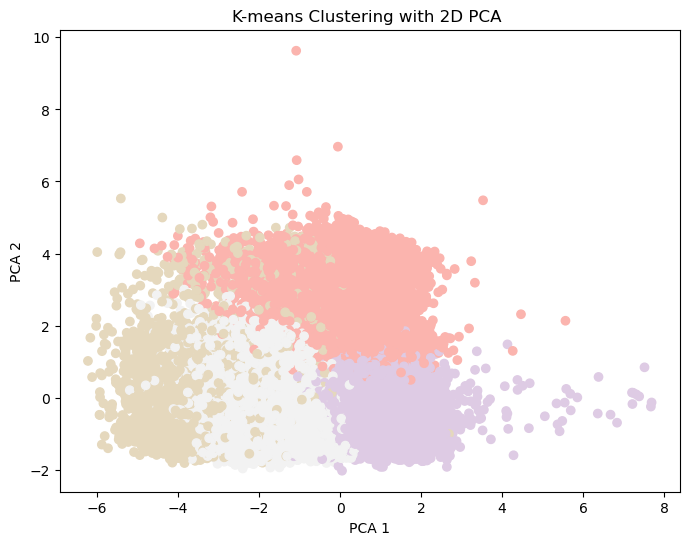

```python
from sklearn.decomposition import PCA

# Pairplot visualization
sns.pairplot(df, hue='Cluster', palette='pastel')
plt.show()

# Alternatively, use PCA for dimensionality reduction and plot
pca = PCA(n_components=2)
df_pca = pca.fit_transform(df_scaled)

# Scatter plot
plt.figure(figsize=(8, 6))
plt.scatter(df_pca[:, 0], df_pca[:, 1], c=clusters, cmap='Pastel1')  # Use the 'Pastel1' colormap for softer colors
plt.xlabel('PCA 1')
plt.ylabel('PCA 2')
plt.title('K-means Clustering with 2D PCA ')
plt.show()
```

#### This analysis applies K-Means clustering to a dataset, visualized in 2D using PCA for dimensionality reduction. The results show:

- Moderately poor cluster separation (silhouette score: 0.23)
- 4 clusters represented in pastel colors in a scatter plot
- PCA simplifies high-dimensional data, retaining significant variance for visual assessment

#### Recommendation:

Further analysis or adjustments to the number of clusters may improve clustering results.

### 3.Data Preprocessing and K-Means Clustering.

```python
features = ['age', 'gender', 'height', 'weight', 'ap_hi', 'ap_lo', 'cholesterol', 'gluc', 'smoke', 'alco', 'active']
print("Selected features:", features)
```

```
Selected features: ['age', 'gender', 'height', 'weight', 'ap_hi', 'ap_lo', 'cholesterol', 'gluc', 'smoke', 'alco', 'active']
```

```python
scaler = StandardScaler()
X_scaled = scaler.fit_transform(df[features])
print(pd.DataFrame(X_scaled, columns=features).head())
```

```
        age    gender    height    weight     ap_hi     ap_lo  cholesterol  \
0 -0.436062  1.364055  0.443452 -0.847873 -0.122182 -0.088238    -0.539322
1  0.307686 -0.733108 -1.018168  0.749831  0.072610 -0.035180     2.400793
2 -0.247997 -0.733108  0.078047 -0.708942  0.007679 -0.141297     2.400793
3 -0.748152  1.364055  0.565254  0.541435  0.137541  0.017879    -0.539322
4 -0.808543 -0.733108 -1.018168 -1.264666 -0.187113 -0.194356    -0.539322

      gluc     smoke      alco    active
0 -0.39572 -0.310879 -0.238384  0.494167
1 -0.39572 -0.310879 -0.238384  0.494167
2 -0.39572 -0.310879 -0.238384 -2.023607
3 -0.39572 -0.310879 -0.238384  0.494167
4 -0.39572 -0.310879 -0.238384 -2.023607
```

```python
km = KMeans(n_clusters=5, random_state=42)
km.fit(X_scaled)
df['cluster_group'] = km.labels_
print(df.head())
```

```
     age  gender  height  weight  ap_hi  ap_lo  cholesterol  gluc  smoke  \
0  18393       2     168    62.0    110     80            1     1      0
1  20228       1     156    85.0    140     90            3     1      0
2  18857       1     165    64.0    130     70            3     1      0
3  17623       2     169    82.0    150    100            1     1      0
4  17474       1     156    56.0    100     60            1     1      0

   alco  active  Cluster  cluster_group
0     0       1        3              3
1     0       1        0              0
2     0       0        0              4
3     0       1        3              3
4     0       0        1              4
```

#### This code streamlines the clustering process for cardiovascular data analysis.

### 4.Scatter Plot of K-Means Clustering Results.

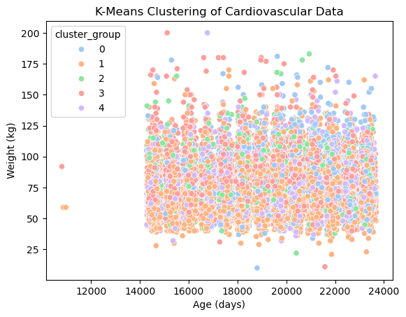

```python
sns.scatterplot(x='age', y='weight', data=df, hue='cluster_group', palette='pastel')
plt.title('K-Means Clustering of Cardiovascular Data')
plt.xlabel('Age (days)')
plt.ylabel('Weight (kg)')
plt.show()
```

#### K-Means Clustering Visualization.

#### A scatter plot illustrating the clustering of cardiovascular data, where:

- X-axis: Age (in days)
- Y-axis: Weight (in kilograms)

### 5.Cluster Group Analysis

```python
most_prominent_cluster_details = df[df['cluster_group'] == 0]
print(most_prominent_cluster_details.head())
```

```
      age  gender  height  weight  ap_hi  ap_lo  cholesterol  gluc  smoke  \
1   20228       1     156    85.0    140     90            3     1      0
6   22113       1     157    93.0    130     80            3     1      0
7   22584       2     178    95.0    130     90            3     3      0
17  16747       1     158    52.0    110     70            1     3      0
22  23046       1     158    90.0    145     85            2     2      0

    alco  active  Cluster  cluster_group
1      0       1        0              0
6      0       1        0              0
7      0       1        0              0
17     0       1        0              0
22     0       1        0              0
```

#### The details of the most prominent cluster group (cluster group 0) are displayed. The table includes various features like age, height, weight, and cholesterol levels, allowing for further analysis of the characteristics of individuals within this specific cluster.

### 5.Model Building with Principal Component Analysis (PCA) and K-Means Clustering.

```python
from sklearn.cluster import KMeans
from sklearn.preprocessing import StandardScaler
from sklearn.decomposition import PCA

scaler = StandardScaler()
X_scaled = scaler.fit_transform(X)

pca = PCA(n_components=2)
X_pca = pca.fit_transform(X_scaled)

kmeans_pca = KMeans(n_clusters=2, random_state=42)
clusters_pca = kmeans_pca.fit_predict(X_pca)

X['pca_cluster'] = clusters_pca
X_train, X_test, y_train, y_test = train_test_split(X, y, test_size=0.3, random_state=42)
```

#### A.)Logistic Regression.

```python
logistic_model = LogisticRegression(max_iter=1000)
logistic_model.fit(X_train, y_train)
```

```
LogisticRegression(max_iter=1000)
```

```python
# Accuracy on test set
logistic_acc_test = accuracy_score(y_test, logistic_model.predict(X_test))
print(f"Logistic Regression Accuracy on Test Set: {logistic_acc_test}")

# Accuracy on training set
logistic_acc_train = accuracy_score(y_train, logistic_model.predict(X_train))
print(f"Logistic Regression Accuracy on Training Set: {logistic_acc_train}")
```

```
Logistic Regression Accuracy on Test Set: 0.7195714285714285
Logistic Regression Accuracy on Training Set: 0.7168571428571429
```

#### B.)Linear Regression.

```python
linear_model = LinearRegression()
linear_model.fit(X_train, y_train)
```

```
LinearRegression()
```

```python
linear_acc_test = accuracy_score(y_test, linear_model.predict(X_test).round())
print(f"Linear Regression Accuracy on Test Set: {linear_acc_test}")

linear_acc_train = accuracy_score(y_train, linear_model.predict(X_train).round())
print(f"Linear Regression Accuracy on Training Set: {linear_acc_train}")
```

```
Linear Regression Accuracy on Test Set: 0.6501428571428571
Linear Regression Accuracy on Training Set: 0.6451224489795918
```

#### C.)Decision Tree Classifier.

```python
dt_model = DecisionTreeClassifier()
dt_model.fit(X_train, y_train)
```

```
DecisionTreeClassifier()
```

```python
# Accuracy on test set
dt_acc_test = accuracy_score(y_test, dt_model.predict(X_test))
print(f"Decision Tree Classifier Accuracy on Test Set: {dt_acc_test}")

# Accuracy on training set
dt_acc_train = accuracy_score(y_train, dt_model.predict(X_train))
print(f"Decision Tree Classifier Accuracy on Training Set: {dt_acc_train}")
```

```
Decision Tree Classifier Accuracy on Test Set: 0.6388571428571429
Decision Tree Classifier Accuracy on Training Set: 0.9998571428571429
```

#### D.)K-Neighbors Classifier.

```python
knn_model = KNeighborsClassifier()
knn_model.fit(X_train, y_train)
```

```
KNeighborsClassifier()
```

```python
# Accuracy on test set
knn_acc_test = accuracy_score(y_test, knn_model.predict(X_test))
print(f"K-Neighbors Classifier Accuracy on Test Set: {knn_acc_test}")

# Accuracy on training set
knn_acc_train = accuracy_score(y_train, knn_model.predict(X_train))
print(f"K-Neighbors Classifier Accuracy on Training Set: {knn_acc_train}")
```

```
K-Neighbors Classifier Accuracy on Test Set: 0.6507142857142857
K-Neighbors Classifier Accuracy on Training Set: 0.7645306122448979
```

#### E.)Naive Bayes.

```python
nb_model = GaussianNB()
nb_model.fit(X_train, y_train)
```

```
GaussianNB()
```

```python
# Accuracy on test set
nb_acc_test = accuracy_score(y_test, nb_model.predict(X_test))
print(f"Naive Bayes Accuracy on Test Set: {nb_acc_test}")

# Accuracy on training set
nb_acc_train = accuracy_score(y_train, nb_model.predict(X_train))
print(f"Naive Bayes Accuracy on Training Set: {nb_acc_train}")
```

```
Naive Bayes Accuracy on Test Set: 0.5951428571428572
Naive Bayes Accuracy on Training Set: 0.598326530612245
```

#### F.)Support Vector Machine (SVM).

```python
svm_model = SVC()
svm_model.fit(X_train, y_train)
```

```
SVC()
```

```python
# Accuracy on test set
svm_acc_test = accuracy_score(y_test, svm_model.predict(X_test))
print(f"Support Vector Machine Accuracy on Test Set: {svm_acc_test}")

# Accuracy on training set
svm_acc_train = accuracy_score(y_train, svm_model.predict(X_train))
print(f"Support Vector Machine Accuracy on Training Set: {svm_acc_train}")
```

```
Support Vector Machine Accuracy on Test Set: 0.7347619047619047
Support Vector Machine Accuracy on Training Set: 0.7333673469387755
```

#### G.)Random Forest Classifier.

```python
rf_model = RandomForestClassifier()
rf_model.fit(X_train, y_train)
```

```
RandomForestClassifier()
```

```python
# Accuracy on test set
rf_acc_test = accuracy_score(y_test, rf_model.predict(X_test))
print(f"Random Forest Accuracy on Test Set: {rf_acc_test}")

# Accuracy on training set
rf_acc_train = accuracy_score(y_train, rf_model.predict(X_train))
print(f"Random Forest Accuracy on Training Set: {rf_acc_train}")
```

```
Random Forest Accuracy on Test Set: 0.7168571428571429
Random Forest Accuracy on Training Set: 0.9998367346938776
```

### H.)Polynomial Regression (Degree-2) Model using Pipeline.

```python
from sklearn.pipeline import make_pipeline

poly_model = make_pipeline(PolynomialFeatures(degree=2), LinearRegression())
poly_model.fit(X_train, y_train)
```

```
Pipeline(steps=[('polynomialfeatures', PolynomialFeatures()),
                ('linearregression', LinearRegression())])
```

###### This code snippet showcases a streamlined approach to creating a degree-2 polynomial regression model using Scikit-learn's `make_pipeline` function. The pipeline seamlessly integrates two key steps:

1. Feature Transformation*: `PolynomialFeatures` converts input data (`X_train`) into polynomial features.
2. Linear Regression*: Fits a linear regression model on the transformed data (`y_train`).

###### By chaining these steps into a single pipeline, this approach simplifies the model building process, enhancing efficiency and readability.

```python
poly_acc_test = accuracy_score(y_test, poly_model.predict(X_test).round())
print(f"Polynomial Regression (Degree-2) Accuracy on Test Set: {poly_acc_test}")

poly_acc_train = accuracy_score(y_train, poly_model.predict(X_train).round())
print(f"Polynomial Regression (Degree-2) Accuracy on Training Set: {poly_acc_train}")
```

```
Polynomial Regression (Degree-2) Accuracy on Test Set: 0.6996666666666667
Polynomial Regression (Degree-2) Accuracy on Training Set: 0.6944897959183673
```

## Results of K-Means Clustering Model: Comprehensive Performance Evaluation for Training and Testing Metrics.

```python
model_list = ['Logistic Regression', 'Linear Regression','DecisionTreeClassifier','KNeighborsClassifier','Naive Bayes','Support Vector Machine','Random Forest','Polynomial Regression(Degree-2)']
train_result_list = [logistic_acc_train*100, linear_acc_train*100, dt_acc_train*100,knn_acc_train*100, nb_acc_train*100,svm_acc_train*100,rf_acc_train*100,poly_acc_train*100]
result_list = [logistic_acc_test*100, linear_acc_test*100, dt_acc_test*100,knn_acc_test*100, nb_acc_test*100,svm_acc_test*100,rf_acc_test*100,poly_acc_test*100]

df_result = pd.DataFrame()
df_result['Model name'] = model_list
df_result['Accuracy Score (Train)'] = train_result_list
df_result['Accuracy Score(Test)'] = result_list

df_result
```

|  | Model name | Accuracy Score (Train) | Accuracy Score(Test) |
| --- | --- | --- | --- |
| 0 | Logistic Regression | 71.685714 | 71.957143 |
| 1 | Linear Regression | 64.512245 | 65.014286 |
| 2 | DecisionTreeClassifier | 99.985714 | 63.885714 |
| 3 | KNeighborsClassifier | 76.453061 | 65.071429 |
| 4 | Naive Bayes | 59.832653 | 59.514286 |
| 5 | Support Vector Machine | 73.336735 | 73.476190 |
| 6 | Random Forest | 99.983673 | 71.685714 |
| 7 | Polynomial Regression(Degree-2) | 69.448980 | 69.966667 |

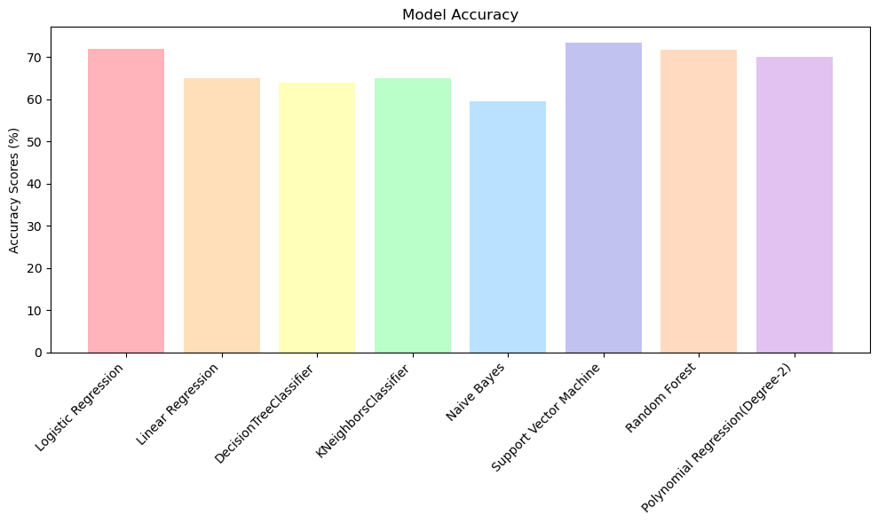

```python
models = ['Logistic Regression', 'Linear Regression', 'DecisionTreeClassifier',
          'KNeighborsClassifier', 'Naive Bayes', 'Support Vector Machine',
          'Random Forest', 'Polynomial Regression(Degree-2)']
acc_scores =[logistic_acc_test*100, linear_acc_test*100, dt_acc_test*100,knn_acc_test*100, nb_acc_test*100,svm_acc_test*100,rf_acc_test*100,poly_acc_test*100]
# Convert to percentage
pastel_colors = ['#FFB3BA', '#FFDFBA', '#FFFFBA', '#BAFFC9', '#BAE1FF',
                 '#C2C2F0', '#FFDAC1', '#E2C2F0']


plt.figure(figsize=(10, 6))
plt.bar(models, acc_scores, color=pastel_colors)
plt.ylabel("Accuracy Scores (%)")
plt.title("Model Accuracy")
plt.xticks(rotation=45, ha='right')
plt.tight_layout()
plt.show()
```